# INN Hotels Project

## EDA

- It is a good idea to explore the data once again after manipulating it.

```python
df.info()
```

```
<class 'pandas.core.frame.DataFrame'>
RangeIndex: 36275 entries, 0 to 36274
Data columns (total 20 columns):
 #   Column                                Non-Null Count  Dtype
---  ------                                --------------  -----
 0   no_of_adults                          36275 non-null  int64
 1   no_of_children                        36275 non-null  int64
 2   no_of_weekend_nights                  36275 non-null  int64
 3   no_of_week_nights                     36275 non-null  int64
 4   type_of_meal_plan                     36275 non-null  object
 5   required_car_parking_space            36275 non-null  int64
 6   room_type_reserved                    36275 non-null  object
 7   lead_time                             36275 non-null  float64
 8   arrival_year                          36275 non-null  int64
 9   arrival_month                         36275 non-null  int64
 10  arrival_date                          36275 non-null  int64
 11  market_segment_type                   36275 non-null  object
 12  repeated_guest                        36275 non-null  int64
 13  no_of_previous_cancellations          36275 non-null  int64
 14  no_of_previous_bookings_not_canceled  36275 non-null  int64
 15  avg_price_per_room                    36275 non-null  float64
 16  no_of_special_requests                36275 non-null  int64
 17  booking_status                        36275 non-null  int64
 18  family                                36275 non-null  float64
 19  length_of_stay                        36275 non-null  int64
dtypes: float64(3), int64(14), object(3)
memory usage: 5.5+ MB
```

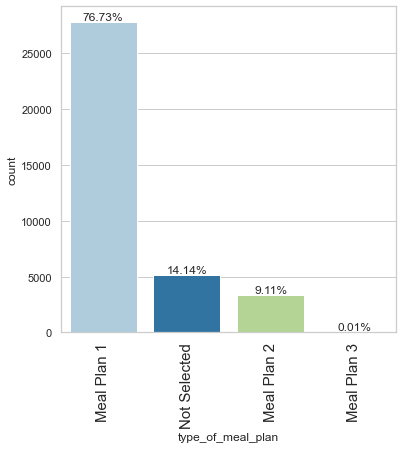

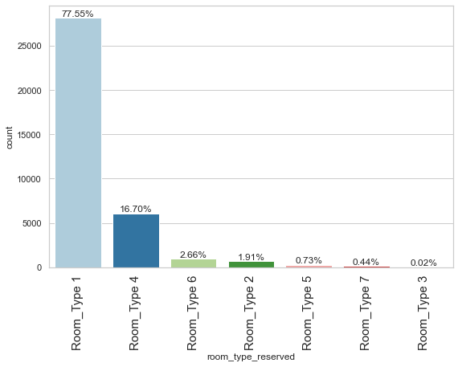

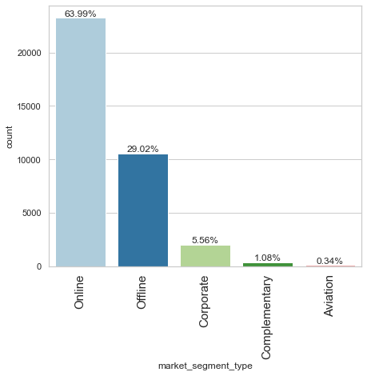

```python
# Plotting categorical data
cat_columns = df.describe(include=["object"]).columns
for col in cat_columns:
    labeled_barplot(df, col, perc=True)
```

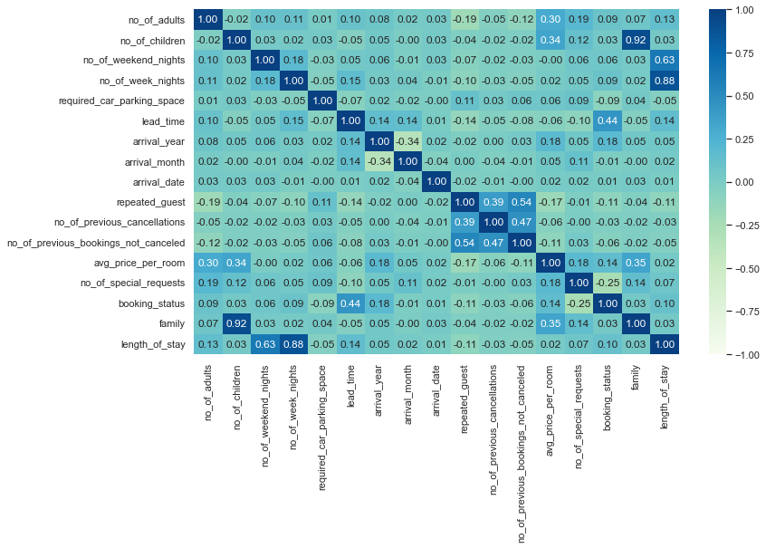

```python
# Plotting correlation heatmap
cols_list = df.select_dtypes(include=np.number).columns.tolist()

plt.figure(figsize=(12, 7))
sns.heatmap(df[cols_list].corr(), annot=True, vmin=-1, vmax=1, fmt=".2f", cmap="GnBu")
plt.show()
```

```
booking_status         0      1    All
type_of_meal_plan
All                24390  11885  36275
Meal Plan 1        19156   8679  27835
Not Selected        3431   1699   5130
Meal Plan 2         1799   1506   3305
Meal Plan 3            4      1      5
------------------------------------------------------------------------------------------------------------------------
```

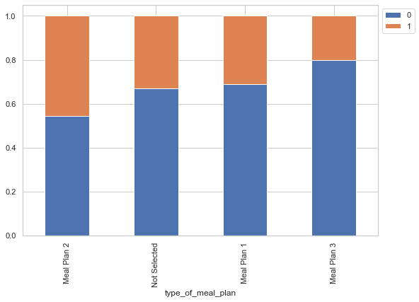

```
booking_status                  0      1    All
required_car_parking_space
All                         24390  11885  36275
0                           23380  11771  35151
1                            1010    114   1124
------------------------------------------------------------------------------------------------------------------------
```

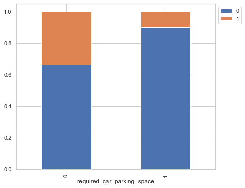

```
booking_status          0      1    All
room_type_reserved
All                 24390  11885  36275
Room_Type 1         19058   9072  28130
Room_Type 4          3988   2069   6057
Room_Type 6           560    406    966
Room_Type 2           464    228    692
Room_Type 5           193     72    265
Room_Type 7           122     36    158
Room_Type 3             5      2      7
------------------------------------------------------------------------------------------------------------------------
```

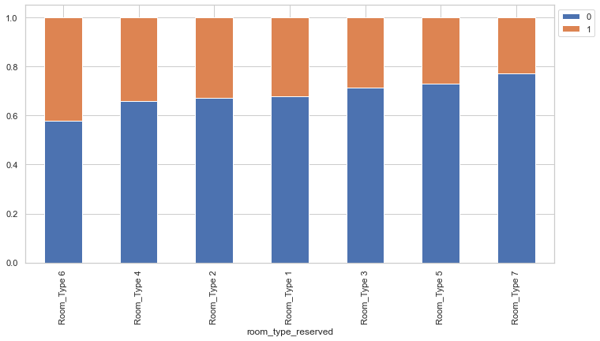

```
booking_status      0      1    All
arrival_month
All             24390  11885  36275
10               3437   1880   5317
9                3073   1538   4611
8                2325   1488   3813
7                1606   1314   2920
6                1912   1291   3203
4                1741    995   2736
5                1650    948   2598
11               2105    875   2980
3                1658    700   2358
2                1274    430   1704
12               2619    402   3021
1                 990     24   1014
------------------------------------------------------------------------------------------------------------------------
```

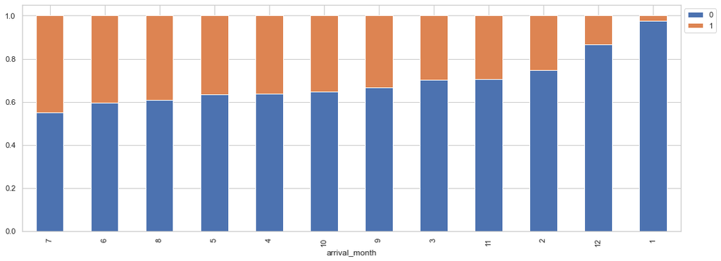

```
booking_status           0      1    All
market_segment_type
All                  24390  11885  36275
Online               14739   8475  23214
Offline               7375   3153  10528
Corporate             1797    220   2017
Aviation                88     37    125
Complementary          391      0    391
------------------------------------------------------------------------------------------------------------------------
```

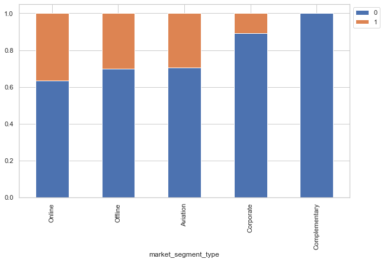

```
booking_status      0      1    All
repeated_guest
All             24390  11885  36275
0               23476  11869  35345
1                 914     16    930
------------------------------------------------------------------------------------------------------------------------
```

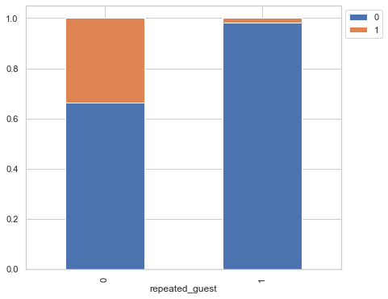

```
booking_status              0      1    All
no_of_special_requests
All                     24390  11885  36275
0                       11232   8545  19777
1                        8670   2703  11373
2                        3727    637   4364
3                         675      0    675
4                          78      0     78
5                           8      0      8
------------------------------------------------------------------------------------------------------------------------
```

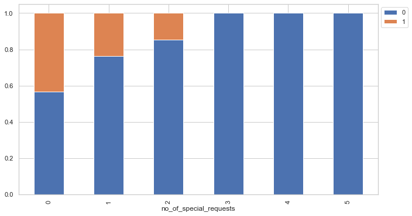

```
booking_status      0      1    All
family
All             24390  11885  36275
0.0             22790  10926  33716
3.0              1020    535   1555
4.0               501    395    896
2.0                67     23     90
5.0                10      5     15
11.0                0      1      1
10.0                1      0      1
12.0                1      0      1
------------------------------------------------------------------------------------------------------------------------
```

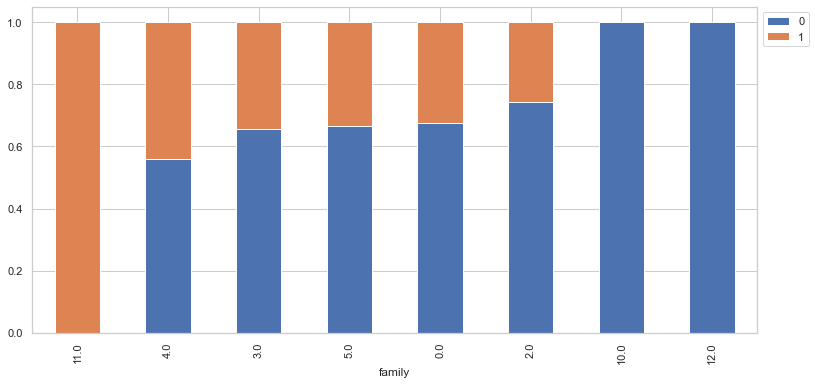

```
booking_status      0      1    All
length_of_stay
All             24390  11885  36275
3                6466   3586  10052
2                5573   2899   8472
4                3952   1941   5893
1                5138   1466   6604
5                1766    823   2589
6                 566    465   1031
7                 590    383    973
8                 100     79    179
10                 51     58    109
9                  58     53    111
14                  5     27     32
15                  5     26     31
13                  3     15     18
12                  9     15     24
11                 24     15     39
20                  3      8     11
16                  1      5      6
19                  1      5      6
17                  1      4      5
18                  0      3      3
21                  1      3      4
22                  0      2      2
0                  76      2     78
23                  1      1      2
24                  0      1      1
------------------------------------------------------------------------------------------------------------------------
```

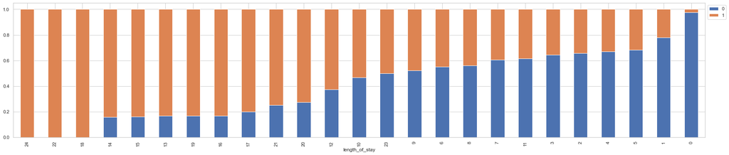

```python
columns = ["type_of_meal_plan","required_car_parking_space","room_type_reserved","arrival_month","market_segment_type","repeated_guest","no_of_special_requests", "family", "length_of_stay"]
for col in columns:
    stacked_barplot(df, col, "booking_status")
```

## Building a Logistic Regression model

**Model prediction notes**

Two cases:

- We predict the guest will not cancel their booking, when they really cancel.
- We predict the guest will cancel their booking, when they do not cancel.

I will chose to use the F1 score because we want to reduce all losses as both cases are just as important. We do not want the hotel to lose customers and taint the company's reputation, or lose on costs and resources for the guest canceling their booking.

```python
# Fitting logistic regression model
logit = sm.Logit(y_train, X_train.astype(float))
lg = logit.fit(disp=False)

print(lg.summary())
```

```
                           Logit Regression Results
==============================================================================
Dep. Variable:         booking_status   No. Observations:                25392
Model:                          Logit   Df Residuals:                    25363
Method:                           MLE   Df Model:                           28
Date:                Thu, 28 Jul 2022   Pseudo R-squ.:                  0.3293
Time:                        17:34:16   Log-Likelihood:                -10792.
converged:                      False   LL-Null:                       -16091.
Covariance Type:            nonrobust   LLR p-value:                     0.000
========================================================================================================
                                           coef    std err          z      P>|z|      [0.025      0.975]
--------------------------------------------------------------------------------------------------------
const                                 -925.4802    120.826     -7.660      0.000   -1162.295    -688.666
no_of_adults                             0.1177      0.038      3.060      0.002       0.042       0.193
no_of_children                           0.2106      0.118      1.785      0.074      -0.021       0.442
no_of_weekend_nights                     0.0580   2.71e+05   2.14e-07      1.000    -5.3e+05     5.3e+05
no_of_week_nights                       -0.0090   2.71e+05  -3.31e-08      1.000    -5.3e+05     5.3e+05
required_car_parking_space              -1.5938      0.138    -11.562      0.000      -1.864      -1.324
lead_time                                0.1099      0.002     58.859      0.000       0.106       0.114
arrival_year                             0.4574      0.060      7.639      0.000       0.340       0.575
arrival_month                           -0.0415      0.006     -6.419      0.000      -0.054      -0.029
arrival_date                             0.0005      0.002      0.254      0.799      -0.003       0.004
repeated_guest                          -2.3461      0.617     -3.805      0.000      -3.555      -1.138
no_of_previous_cancellations             0.2662      0.086      3.107      0.002       0.098       0.434
no_of_previous_bookings_not_canceled    -0.1726      0.153     -1.131      0.258      -0.472       0.127
avg_price_per_room                       0.0188      0.001     25.388      0.000       0.017       0.020
no_of_special_requests                  -1.4687      0.030    -48.776      0.000      -1.528      -1.410
family                                  -0.0277      0.053     -0.524      0.601      -0.131       0.076
length_of_stay                           0.0488   2.71e+05    1.8e-07      1.000    -5.3e+05     5.3e+05
type_of_meal_plan_Meal Plan 2            0.1758      0.067      2.638      0.008       0.045       0.306
type_of_meal_plan_Meal Plan 3           17.1711   3631.376      0.005      0.996   -7100.196    7134.538
type_of_meal_plan_Not Selected           0.2764      0.053      5.201      0.000       0.172       0.381
room_type_reserved_Room_Type 2          -0.3851      0.139     -2.777      0.005      -0.657      -0.113
room_type_reserved_Room_Type 3          -0.0030      1.310     -0.002      0.998      -2.571       2.565
room_type_reserved_Room_Type 4          -0.2859      0.054     -5.326      0.000      -0.391      -0.181
room_type_reserved_Room_Type 5          -0.7184      0.209     -3.436      0.001      -1.128      -0.309
room_type_reserved_Room_Type 6          -0.9477      0.147     -6.458      0.000      -1.235      -0.660
room_type_reserved_Room_Type 7          -1.3995      0.293     -4.776      0.000      -1.974      -0.825
market_segment_type_Complementary      -40.1423   4.93e+05  -8.15e-05      1.000   -9.65e+05    9.65e+05
market_segment_type_Corporate           -1.1967      0.266     -4.498      0.000      -1.718      -0.675
market_segment_type_Offline             -2.1995      0.255     -8.636      0.000      -2.699      -1.700
market_segment_type_Online              -0.4023      0.251     -1.601      0.109      -0.895       0.090
========================================================================================================
```

```python
# Defining a function to compute different metrics to check performance of a classification model
def model_performance_classification_statsmodels(model, predictors, target, threshold):
    pred_temp = model.predict(predictors) > threshold
    pred = np.round(pred_temp)
    acc = accuracy_score(target, pred)  # to compute Accuracy
    recall = recall_score(target, pred)  # to compute Recall
    precision = precision_score(target, pred)  # to compute Precision
    f1 = f1_score(target, pred)  # to compute F1-score
    # creating a dataframe of metrics
    df_perf = pd.DataFrame({"Accuracy": acc, "Recall": recall, "Precision": precision, "F1": f1}, index=[0])
    return df_perf
```

```python
# Defining the confusion_matrix_statsmodels function to plot the confusion matrix of a classification model
def confusion_matrix_statsmodels(model, predictors, target, threshold):
    y_pred = model.predict(predictors) > threshold
    cm = confusion_matrix(target, y_pred)
    labels = np.asarray(
        [
            ["{0:0.0f}".format(item) + "\n{0:.2%}".format(item / cm.flatten().sum())]
            for item in cm.flatten()
        ]
    ).reshape(2, 2)
    plt.figure(figsize=(6, 4))
    sns.heatmap(cm, annot=labels, fmt="")
    plt.ylabel("True label")
    plt.xlabel("Predicted label")
```

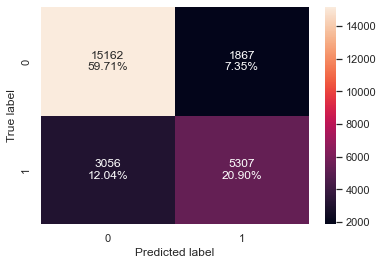

```python
confusion_matrix_statsmodels(lg, X_train, y_train, threshold=0.5)
```

```python
print("Training performance:")
model_performance_classification_statsmodels(lg, X_train, y_train, threshold=0.5)
```

```
Training performance:
```

|  | Accuracy | Recall | Precision | F1 |
| --- | --- | --- | --- | --- |
| 0 | 0.8 | 0.6 | 0.7 | 0.7 |

## Checking Multicollinearity

- In order to make statistical inferences from a logistic regression model, it is important to ensure that there is no multicollinearity present in the data.

```python
# Function for calculating the VIF for each variable
def checking_vif(ind_v):
    vif = pd.DataFrame()
    vif["feature"] = ind_v.columns
    vif["VIF"] = [variance_inflation_factor(ind_v.values, i) for i in range(len(ind_v.columns))]
    return vif
```

```python
checking_vif(X_train)
```

|  | feature | VIF |
| --- | --- | --- |
| 0 | const | 39468662.7 |
| 1 | no_of_adults | 1.4 |
| 2 | no_of_children | 8.6 |
| 3 | no_of_weekend_nights | inf |
| 4 | no_of_week_nights | inf |
| 5 | required_car_parking_space | 1.0 |
| 6 | lead_time | 1.4 |
| 7 | arrival_year | 1.4 |
| 8 | arrival_month | 1.3 |
| 9 | arrival_date | 1.0 |
| 10 | repeated_guest | 1.8 |
| 11 | no_of_previous_cancellations | 1.4 |
| 12 | no_of_previous_bookings_not_canceled | 1.7 |
| 13 | avg_price_per_room | 2.1 |
| 14 | no_of_special_requests | 1.2 |
| 15 | family | 7.5 |
| 16 | length_of_stay | inf |
| 17 | type_of_meal_plan_Meal Plan 2 | 1.3 |
| 18 | type_of_meal_plan_Meal Plan 3 | 1.0 |
| 19 | type_of_meal_plan_Not Selected | 1.3 |
| 20 | room_type_reserved_Room_Type 2 | 1.2 |
| 21 | room_type_reserved_Room_Type 3 | 1.0 |
| 22 | room_type_reserved_Room_Type 4 | 1.4 |
| 23 | room_type_reserved_Room_Type 5 | 1.0 |
| 24 | room_type_reserved_Room_Type 6 | 2.0 |
| 25 | room_type_reserved_Room_Type 7 | 1.1 |
| 26 | market_segment_type_Complementary | 4.5 |
| 27 | market_segment_type_Corporate | 16.9 |
| 28 | market_segment_type_Offline | 64.1 |
| 29 | market_segment_type_Online | 71.2 |

```python
# Dropping high VIF variables
X_train1 = X_train.drop(['no_of_children'], axis=1)
logit1 = sm.Logit(y_train, X_train1.astype(float))
model1 = logit1.fit(disp=False)
checking_vif(X_train1)
```

|  | feature | VIF |
| --- | --- | --- |
| 0 | const | 39467608.7 |
| 1 | no_of_adults | 1.3 |
| 2 | no_of_weekend_nights | inf |
| 3 | no_of_week_nights | inf |
| 4 | required_car_parking_space | 1.0 |
| 5 | lead_time | 1.4 |
| 6 | arrival_year | 1.4 |
| 7 | arrival_month | 1.3 |
| 8 | arrival_date | 1.0 |
| 9 | repeated_guest | 1.8 |
| 10 | no_of_previous_cancellations | 1.4 |
| 11 | no_of_previous_bookings_not_canceled | 1.7 |
| 12 | avg_price_per_room | 2.1 |
| 13 | no_of_special_requests | 1.2 |
| 14 | family | 1.7 |
| 15 | length_of_stay | inf |
| 16 | type_of_meal_plan_Meal Plan 2 | 1.3 |
| 17 | type_of_meal_plan_Meal Plan 3 | 1.0 |
| 18 | type_of_meal_plan_Not Selected | 1.3 |
| 19 | room_type_reserved_Room_Type 2 | 1.0 |
| 20 | room_type_reserved_Room_Type 3 | 1.0 |
| 21 | room_type_reserved_Room_Type 4 | 1.4 |
| 22 | room_type_reserved_Room_Type 5 | 1.0 |
| 23 | room_type_reserved_Room_Type 6 | 1.8 |
| 24 | room_type_reserved_Room_Type 7 | 1.1 |
| 25 | market_segment_type_Complementary | 4.5 |
| 26 | market_segment_type_Corporate | 16.9 |
| 27 | market_segment_type_Offline | 64.1 |
| 28 | market_segment_type_Online | 71.1 |

```python
X_train2 = X_train1.drop(['no_of_weekend_nights'], axis=1)
logit2 = sm.Logit(y_train, X_train2.astype(float))
model2 = logit2.fit(disp=False)
checking_vif(X_train2)
```

|  | feature | VIF |
| --- | --- | --- |
| 0 | const | 39467608.7 |
| 1 | no_of_adults | 1.3 |
| 2 | no_of_week_nights | 4.4 |
| 3 | required_car_parking_space | 1.0 |
| 4 | lead_time | 1.4 |
| 5 | arrival_year | 1.4 |
| 6 | arrival_month | 1.3 |
| 7 | arrival_date | 1.0 |
| 8 | repeated_guest | 1.8 |
| 9 | no_of_previous_cancellations | 1.4 |
| 10 | no_of_previous_bookings_not_canceled | 1.7 |
| 11 | avg_price_per_room | 2.1 |
| 12 | no_of_special_requests | 1.2 |
| 13 | family | 1.7 |
| 14 | length_of_stay | 4.5 |
| 15 | type_of_meal_plan_Meal Plan 2 | 1.3 |
| 16 | type_of_meal_plan_Meal Plan 3 | 1.0 |
| 17 | type_of_meal_plan_Not Selected | 1.3 |
| 18 | room_type_reserved_Room_Type 2 | 1.0 |
| 19 | room_type_reserved_Room_Type 3 | 1.0 |
| 20 | room_type_reserved_Room_Type 4 | 1.4 |
| 21 | room_type_reserved_Room_Type 5 | 1.0 |
| 22 | room_type_reserved_Room_Type 6 | 1.8 |
| 23 | room_type_reserved_Room_Type 7 | 1.1 |
| 24 | market_segment_type_Complementary | 4.5 |
| 25 | market_segment_type_Corporate | 16.9 |
| 26 | market_segment_type_Offline | 64.1 |
| 27 | market_segment_type_Online | 71.1 |

```python
# Dropping high p-values
cols = X_train2.columns.tolist()

max_p_value = 1

while len(cols) > 0:
    x_train_aux = X_train[cols]
    model = sm.Logit(y_train, x_train_aux).fit(disp=False)
    p_values = model.pvalues
    max_p_value = max(p_values)
    feature_with_p_max = p_values.idxmax()
    if max_p_value > 0.05:
        cols.remove(feature_with_p_max)
    else:
        break

selected_features = cols
print(selected_features)
```

[output not shown]

```python
X_train3 = X_train2[selected_features]
X_test1 = X_test[selected_features]
```

```python
# Fitting logistic regression model 3 as the final model
logit3 = sm.Logit(y_train, X_train3.astype(float))
model3 = logit3.fit(disp=False)

print(model3.summary())
```

```
                           Logit Regression Results
==============================================================================
Dep. Variable:         booking_status   No. Observations:                25392
Model:                          Logit   Df Residuals:                    25370
Method:                           MLE   Df Model:                           21
Date:                Thu, 28 Jul 2022   Pseudo R-squ.:                  0.3282
Time:                        17:34:20   Log-Likelihood:                -10810.
converged:                       True   LL-Null:                       -16091.
Covariance Type:            nonrobust   LLR p-value:                     0.000
==================================================================================================
                                     coef    std err          z      P>|z|      [0.025      0.975]
--------------------------------------------------------------------------------------------------
const                           -917.1417    120.472     -7.613      0.000   -1153.262    -681.022
no_of_adults                       0.0969      0.037      2.619      0.009       0.024       0.169
no_of_week_nights                 -0.0671      0.025     -2.675      0.007      -0.116      -0.018
required_car_parking_space        -1.5949      0.138    -11.566      0.000      -1.865      -1.325
lead_time                          0.1100      0.002     59.235      0.000       0.106       0.114
arrival_year                       0.4531      0.060      7.589      0.000       0.336       0.570
arrival_month                     -0.0424      0.006     -6.570      0.000      -0.055      -0.030
repeated_guest                    -2.7416      0.557     -4.921      0.000      -3.834      -1.650
no_of_previous_cancellations       0.2294      0.077      2.990      0.003       0.079       0.380
avg_price_per_room                 0.0192      0.001     26.336      0.000       0.018       0.021
no_of_special_requests            -1.4689      0.030    -48.867      0.000      -1.528      -1.410
family                             0.0526      0.026      2.045      0.041       0.002       0.103
length_of_stay                     0.1090      0.020      5.518      0.000       0.070       0.148
type_of_meal_plan_Meal Plan 2      0.1666      0.067      2.504      0.012       0.036       0.297
type_of_meal_plan_Not Selected     0.2863      0.053      5.404      0.000       0.182       0.390
room_type_reserved_Room_Type 2    -0.2863      0.127     -2.246      0.025      -0.536      -0.036
room_type_reserved_Room_Type 4    -0.2790      0.053     -5.231      0.000      -0.383      -0.174
room_type_reserved_Room_Type 5    -0.7293      0.208     -3.503      0.000      -1.137      -0.321
room_type_reserved_Room_Type 6    -0.8862      0.139     -6.353      0.000      -1.160      -0.613
room_type_reserved_Room_Type 7    -1.3856      0.290     -4.774      0.000      -1.955      -0.817
market_segment_type_Corporate     -0.7972      0.103     -7.755      0.000      -0.999      -0.596
market_segment_type_Offline       -1.7883      0.052    -34.407      0.000      -1.890      -1.686
==================================================================================================
```

- Positive coefficient values show the probability of a customer canceling their booking increases with the increase of the corresponding attribute.
- Negative coefficient values show the probability of a customer canceling their booking decreaeses with the increase of the corresponding attribute.

```python
# Looking at log(odds) and converting coefficients to odds
odds = np.exp(model3.params)
perc_change_odds = (np.exp(model3.params) - 1) * 100

pd.set_option("display.max_columns", None)
pd.DataFrame({"Odds": odds, "Change_odd%": perc_change_odds}, index=X_train3.columns).T
```

|  | const | no_of_adults | no_of_week_nights | required_car_parking_space | lead_time | arrival_year | arrival_month | repeated_guest | no_of_previous_cancellations | avg_price_per_room | no_of_special_requests | family | length_of_stay | type_of_meal_plan_Meal Plan 2 | type_of_meal_plan_Not Selected | room_type_reserved_Room_Type 2 | room_type_reserved_Room_Type 4 | room_type_reserved_Room_Type 5 | room_type_reserved_Room_Type 6 | room_type_reserved_Room_Type 7 | market_segment_type_Corporate | market_segment_type_Offline |
| --- | --- | --- | --- | --- | --- | --- | --- | --- | --- | --- | --- | --- | --- | --- | --- | --- | --- | --- | --- | --- | --- | --- |
| Odds | 0.0 | 1.1 | 0.9 | 0.2 | 1.1 | 1.6 | 1.0 | 0.1 | 1.3 | 1.0 | 0.2 | 1.1 | 1.1 | 1.2 | 1.3 | 0.8 | 0.8 | 0.5 | 0.4 | 0.3 | 0.5 | 0.2 |
| Change_odd% | -100.0 | 10.2 | -6.5 | -79.7 | 11.6 | 57.3 | -4.1 | -93.6 | 25.8 | 1.9 | -77.0 | 5.4 | 11.5 | 18.1 | 33.1 | -24.9 | -24.3 | -51.8 | -58.8 | -75.0 | -54.9 | -83.3 |

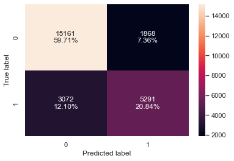

```python
# Checking performance on training set
confusion_matrix_statsmodels(model3, X_train3, y_train, threshold=0.5)
```

```python
print("Training performance:")
log_reg_model_train_perf = model_performance_classification_statsmodels(model3, X_train3, y_train, threshold=0.5)
log_reg_model_train_perf
```

```
Training performance:
```

|  | Accuracy | Recall | Precision | F1 |
| --- | --- | --- | --- | --- |
| 0 | 0.8 | 0.6 | 0.7 | 0.7 |

```python
# Dropping columns on testing set that were dropped on training set model 3
X_test2 = X_test1[list(X_train3.columns)]
```

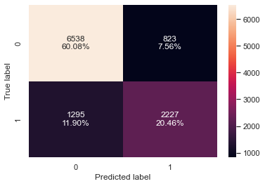

```python
# Checking performance on testing set
confusion_matrix_statsmodels(model3, X_test2, y_test, threshold=0.5)
```

```python
print("Testing performance:")
log_reg_model_test_perf = model_performance_classification_statsmodels(model3, X_test2, y_test, threshold=0.5)
log_reg_model_test_perf
```

```
Testing performance:
```

|  | Accuracy | Recall | Precision | F1 |
| --- | --- | --- | --- | --- |
| 0 | 0.8 | 0.6 | 0.7 | 0.7 |

- The model is giving the same F1 score on both train and test sets (0.7).
- The model does not seem to be overfitting, however, the F1 score could be improved.

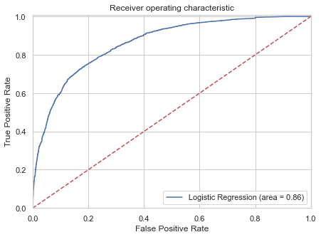

```python
# Looking at ROC-AUC
logit_roc_auc_train = roc_auc_score(y_train, model3.predict(X_train3))
fpr, tpr, thresholds = roc_curve(y_train, model3.predict(X_train3))
plt.figure(figsize=(7, 5))
plt.plot(fpr, tpr, label="Logistic Regression (area = %0.2f)" % logit_roc_auc_train)
plt.plot([0, 1], [0, 1], "r--")
plt.xlim([0.0, 1.0])
plt.ylim([0.0, 1.01])
plt.xlabel("False Positive Rate")
plt.ylabel("True Positive Rate")
plt.title("Receiver operating characteristic")
plt.legend(loc="lower right")
plt.show()
```

```python
# Finding optimal threshold
fpr, tpr, thresholds = roc_curve(y_train, model3.predict(X_train3))

optimal_idx = np.argmax(tpr - fpr)
optimal_threshold_auc_roc = thresholds[optimal_idx]
print(optimal_threshold_auc_roc)
```

```
0.37119413410086693
```

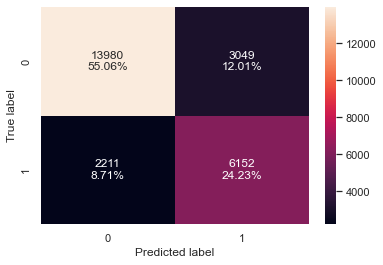

```python
# Checking performance on training set
confusion_matrix_statsmodels(model3, X_train3, y_train, threshold=optimal_threshold_auc_roc)
```

```python
log_reg_model_train_perf_threshold_auc_roc = model_performance_classification_statsmodels(
    model3, X_train3, y_train, threshold=optimal_threshold_auc_roc)

print("Training performance:")
log_reg_model_train_perf_threshold_auc_roc
```

```
Training performance:
```

|  | Accuracy | Recall | Precision | F1 |
| --- | --- | --- | --- | --- |
| 0 | 0.8 | 0.7 | 0.7 | 0.7 |

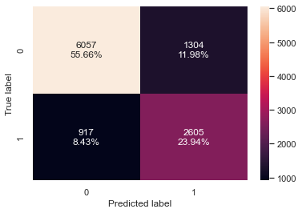

```python
# Checking performance on testing set
confusion_matrix_statsmodels(model3, X_test2, y_test, threshold=optimal_threshold_auc_roc)
```

```python
log_reg_model_test_perf_threshold_auc_roc = model_performance_classification_statsmodels(
    model3, X_test2, y_test, threshold=optimal_threshold_auc_roc)

print("Testing performance:")
log_reg_model_test_perf_threshold_auc_roc
```

```
Testing performance:
```

|  | Accuracy | Recall | Precision | F1 |
| --- | --- | --- | --- | --- |
| 0 | 0.8 | 0.7 | 0.7 | 0.7 |

- Only the recall has increased from 0.6 to 0.7, all other metrics have stayed the same.

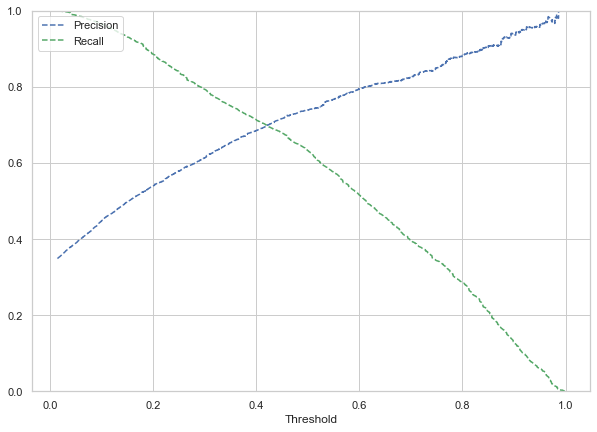

```python
# Plotting precision-recall curve
y_scores = model3.predict(X_train3)
prec, rec, tre = precision_recall_curve(y_train, y_scores,)


def plot_prec_recall_vs_tresh(precisions, recalls, thresholds):
    plt.plot(thresholds, precisions[:-1], "b--", label="Precision")
    plt.plot(thresholds, recalls[:-1], "g--", label="Recall")
    plt.xlabel("Threshold")
    plt.legend(loc="upper left")
    plt.ylim([0, 1])


plt.figure(figsize=(10, 7))
plot_prec_recall_vs_tresh(prec, rec, tre)
plt.show()
```

```python
# Setting the optimal threshold value
optimal_threshold_curve = 0.42
```

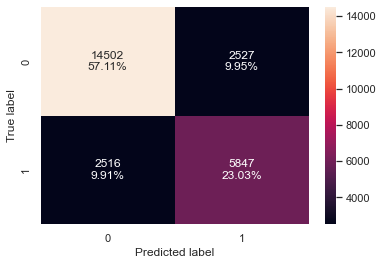

```python
# Checking training set performance
confusion_matrix_statsmodels(model3, X_train3, y_train, threshold=optimal_threshold_curve)
```

```python
log_reg_model_train_perf_threshold_curve = model_performance_classification_statsmodels(
    model3, X_train3, y_train, threshold=optimal_threshold_curve
)
print("Training performance:")
log_reg_model_train_perf_threshold_curve
```

```
Training performance:
```

|  | Accuracy | Recall | Precision | F1 |
| --- | --- | --- | --- | --- |
| 0 | 0.8 | 0.7 | 0.7 | 0.7 |

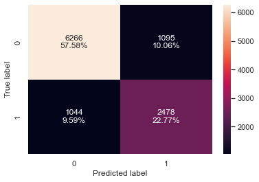

```python
# Checking testing set performance
confusion_matrix_statsmodels(model3, X_test2, y_test, threshold=optimal_threshold_curve)
```

```python
log_reg_model_test_perf = model_performance_classification_statsmodels(
    model3, X_test2, y_test, threshold=optimal_threshold_curve
)
print("Testing performance:")
log_reg_model_test_perf
```

```
Testing performance:
```

|  | Accuracy | Recall | Precision | F1 |
| --- | --- | --- | --- | --- |
| 0 | 0.8 | 0.7 | 0.7 | 0.7 |

- There seems to be no change to the metric values after finding the optmial threshold

## Model performance evaluation

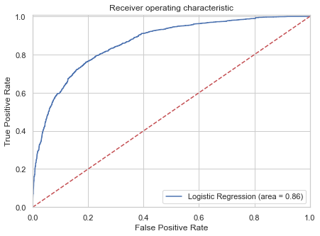

```python
logit_roc_auc_train = roc_auc_score(y_test, model3.predict(X_test2))
fpr, tpr, thresholds = roc_curve(y_test, model3.predict(X_test2))
plt.figure(figsize=(7, 5))
plt.plot(fpr, tpr, label="Logistic Regression (area = %0.2f)" % logit_roc_auc_train)
plt.plot([0, 1], [0, 1], "r--")
plt.xlim([0.0, 1.0])
plt.ylim([0.0, 1.01])
plt.xlabel("False Positive Rate")
plt.ylabel("True Positive Rate")
plt.title("Receiver operating characteristic")
plt.legend(loc="lower right")
plt.show()
```

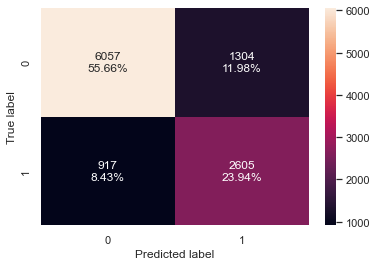

```python
# Checking test set performance with threshold at 0.37
confusion_matrix_statsmodels(model3, X_test2, y_test, threshold=optimal_threshold_auc_roc)
```

```python
log_reg_model_test_perf_threshold_auc_roc = model_performance_classification_statsmodels(
    model3, X_test2, y_test, threshold=optimal_threshold_auc_roc
)
print("Test performance:")
log_reg_model_test_perf_threshold_auc_roc
```

```
Test performance:
```

|  | Accuracy | Recall | Precision | F1 |
| --- | --- | --- | --- | --- |
| 0 | 0.8 | 0.7 | 0.7 | 0.7 |

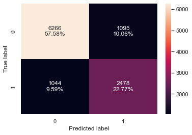

```python
# Checking test set performance with threshold at 0.42
confusion_matrix_statsmodels(model3, X_test2, y_test, threshold=optimal_threshold_curve)
```

```python
log_reg_model_test_perf_threshold_curve = model_performance_classification_statsmodels(
    model3, X_test2, y_test, threshold=optimal_threshold_curve
)
print("Test performance:")
log_reg_model_test_perf_threshold_curve
```

```
Test performance:
```

|  | Accuracy | Recall | Precision | F1 |
| --- | --- | --- | --- | --- |
| 0 | 0.8 | 0.7 | 0.7 | 0.7 |

## Final Model Summary

```python
# Training set performance comparison
train_comp_df = pd.concat(
    [
        log_reg_model_train_perf.T,
        log_reg_model_train_perf_threshold_auc_roc.T,
        log_reg_model_train_perf_threshold_curve.T,
    ],
    axis=1,
)
train_comp_df.columns = [
    "Logistic Regression-default Threshold (0.5)",
    "Logistic Regression-0.37 Threshold",
    "Logistic Regression-0.42 Threshold",
]

print("Training performance comparison:")
train_comp_df
```

```
Training performance comparison:
```

|  | Logistic Regression-default Threshold (0.5) | Logistic Regression-0.37 Threshold | Logistic Regression-0.42 Threshold |
| --- | --- | --- | --- |
| Accuracy | 0.8 | 0.8 | 0.8 |
| Recall | 0.6 | 0.7 | 0.7 |
| Precision | 0.7 | 0.7 | 0.7 |
| F1 | 0.7 | 0.7 | 0.7 |

```python
# Testing set performance comparison
test_comp_df = pd.concat(
    [
        log_reg_model_test_perf.T,
        log_reg_model_test_perf_threshold_auc_roc.T,
        log_reg_model_test_perf_threshold_curve.T,
    ],
    axis=1,
)
test_comp_df.columns = [
    "Logistic Regression-default Threshold (0.5)",
    "Logistic Regression-0.37 Threshold",
    "Logistic Regression-0.42 Threshold",
]

print("Testing performance comparison:")
test_comp_df
```

```
Testing performance comparison:
```

[output not shown]

- Overall, the model performs well on both the training and testing sets, without overfitting.
- There is not much improvement in the model performance from the default threshold 0.5 compared to the auc-roc and optimal thresholds.
- We can select the optimal threshold (0.42) as the final model as it gives better false positive/negative percentages in the confusion matrix compared to the onfusion matrix with threshold 0.37.

## Building a Decision Tree model

```python
X = df.drop(["booking_status"], axis=1)
Y = df["booking_status"]

X = pd.get_dummies(X, drop_first=True)

X_train, X_test, y_train, y_test = train_test_split(X, Y, test_size=0.30, random_state=1)
```

```python
print("Shape of Training set : ", X_train.shape)
print("Shape of test set : ", X_test.shape)
print("Percentage of classes in training set:")
print(y_train.value_counts(normalize=True))
print("Percentage of classes in test set:")
print(y_test.value_counts(normalize=True))
```

```
Shape of Training set :  (25392, 29)
Shape of test set :  (10883, 29)
Percentage of classes in training set:
0   0.7
1   0.3
Name: booking_status, dtype: float64
Percentage of classes in test set:
0   0.7
1   0.3
Name: booking_status, dtype: float64
```

```python
model = DecisionTreeClassifier(random_state=1)
model.fit(X_train, y_train)
```

```
DecisionTreeClassifier(random_state=1)
```

```python
# Defining a function to compute different metrics to check performance of a classification model
def model_performance_classification_sklearn(model, predictors, target):
    pred = model.predict(predictors)
    acc = accuracy_score(target, pred)  # to compute Accuracy
    recall = recall_score(target, pred)  # to compute Recall
    precision = precision_score(target, pred)  # to compute Precision
    f1 = f1_score(target, pred)  # to compute F1-score
    df_perf = pd.DataFrame(
        {"Accuracy": acc, "Recall": recall, "Precision": precision, "F1": f1,},
        index=[0],
    )
    return df_perf
```

```python
# Defining the confusion_matrix_statsmodels function to plot the confusion matrix of a classification model
def confusion_matrix_sklearn(model, predictors, target):
    y_pred = model.predict(predictors)
    cm = confusion_matrix(target, y_pred)
    labels = np.asarray(
        [
            ["{0:0.0f}".format(item) + "\n{0:.2%}".format(item / cm.flatten().sum())]
            for item in cm.flatten()
        ]
    ).reshape(2, 2)

    plt.figure(figsize=(6, 4))
    sns.heatmap(cm, annot=labels, fmt="")
    plt.ylabel("True label")
    plt.xlabel("Predicted label")
```

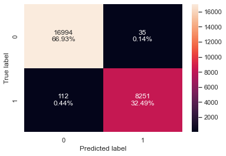

```python
# Checking performance on training set
confusion_matrix_sklearn(model, X_train, y_train)
```

```python
dtree_perf_train = model_performance_classification_sklearn(model, X_train, y_train)
dtree_perf_train
```

|  | Accuracy | Recall | Precision | F1 |
| --- | --- | --- | --- | --- |
| 0 | 1.0 | 1.0 | 1.0 | 1.0 |

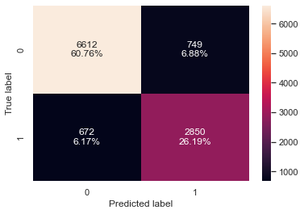

```python
# Checking performance on testing set
confusion_matrix_sklearn(model, X_test, y_test)
```

```python
dtree_perf_test = model_performance_classification_sklearn(model, X_test, y_test)
dtree_perf_test
```

|  | Accuracy | Recall | Precision | F1 |
| --- | --- | --- | --- | --- |
| 0 | 0.9 | 0.8 | 0.8 | 0.8 |

## Do we need to prune the tree?

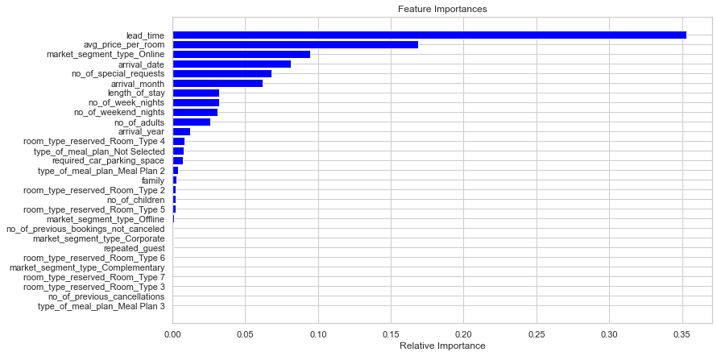

```python
# Looking at the important features in the dataset
feature_names = list(X_train.columns)
importances = model.feature_importances_
indices = np.argsort(importances)

plt.figure(figsize=(12, 7))
plt.title("Feature Importances")
plt.barh(range(len(indices)), importances[indices], color="blue", align="center")
plt.yticks(range(len(indices)), [feature_names[i] for i in indices])
plt.xlabel("Relative Importance")
plt.show()
```

- Top three important features currently are lead_time, avg_price_per_room and market_segment_type_Online.

**Pre-pruning**

```python
# Choosing the type of classifier, hyperparameters, and F1 score
estimator = DecisionTreeClassifier(random_state=1, class_weight="balanced")

parameters = {
    "max_depth": np.arange(2, 7, 2),
    "max_leaf_nodes": [50, 75, 150, 250],
    "min_samples_split": [10, 30, 50, 70],
}

acc_scorer = make_scorer(f1_score)

# Running grid search cv and set estimator
grid_obj = GridSearchCV(estimator, parameters, scoring=acc_scorer, cv=5)
grid_obj = grid_obj.fit(X_train, y_train)

estimator = grid_obj.best_estimator_

# Fitting the best algorithm
estimator.fit(X_train, y_train)
```

```
DecisionTreeClassifier(class_weight='balanced', max_depth=6, max_leaf_nodes=50,
                       min_samples_split=10, random_state=1)
```

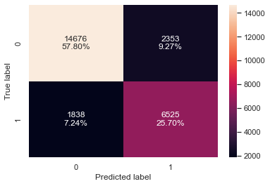

```python
# Checking training set performance
confusion_matrix_sklearn(estimator, X_train, y_train)
```

```python
dtree_tune_perf_train = model_performance_classification_sklearn(estimator, X_train, y_train)
dtree_tune_perf_train
```

|  | Accuracy | Recall | Precision | F1 |
| --- | --- | --- | --- | --- |
| 0 | 0.8 | 0.8 | 0.7 | 0.8 |

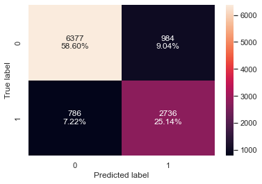

```python
# Checking testing set performance
confusion_matrix_sklearn(estimator, X_test, y_test)
```

```python
dtree_tune_perf_test = model_performance_classification_sklearn(estimator, X_test, y_test)
dtree_tune_perf_test
```

|  | Accuracy | Recall | Precision | F1 |
| --- | --- | --- | --- | --- |
| 0 | 0.8 | 0.8 | 0.7 | 0.8 |

- The model seems to generalise well on the testing set.

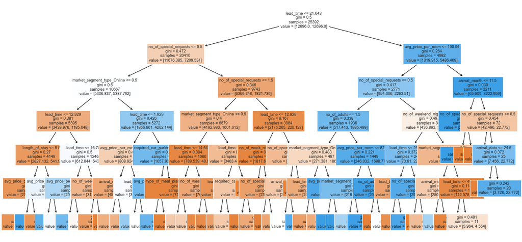

```python
# Decision tree visualization
plt.figure(figsize=(20, 10))
out = tree.plot_tree(
    estimator,
    feature_names=feature_names,
    filled=True,
    fontsize=9,
    node_ids=False,
    class_names=None,
)

# For loop to add arrows
for o in out:
    arrow = o.arrow_patch
    if arrow is not None:
        arrow.set_edgecolor("black")
        arrow.set_linewidth(1)
plt.show()
```

```python
print(tree.export_text(estimator, feature_names=feature_names, show_weights=True))
```

```
|--- lead_time <= 21.64
|   |--- no_of_special_requests <= 0.50
|   |   |--- market_segment_type_Online <= 0.50
|   |   |   |--- lead_time <= 12.93
|   |   |   |   |--- length_of_stay <= 5.50
|   |   |   |   |   |--- avg_price_per_room <= 201.50
|   |   |   |   |   |   |--- weights: [2739.90, 419.00] class: 0
|   |   |   |   |   |--- avg_price_per_room >  201.50
|   |   |   |   |   |   |--- weights: [1.49, 25.81] class: 1
|   |   |   |   |--- length_of_stay >  5.50
|   |   |   |   |   |--- avg_price_per_room <= 92.80
|   |   |   |   |   |   |--- weights: [68.59, 12.14] class: 0
|   |   |   |   |   |--- avg_price_per_room >  92.80
|   |   |   |   |   |   |--- weights: [17.15, 85.01] class: 1
|   |   |   |--- lead_time >  12.93
|   |   |   |   |--- lead_time <= 16.79
|   |   |   |   |   |--- avg_price_per_room <= 93.58
|   |   |   |   |   |   |--- weights: [214.72, 227.72] class: 1
|   |   |   |   |   |--- avg_price_per_room >  93.58
|   |   |   |   |   |   |--- weights: [82.76, 285.41] class: 1
|   |   |   |   |--- lead_time >  16.79
|   |   |   |   |   |--- no_of_week_nights <= 1.50
|   |   |   |   |   |   |--- weights: [87.23, 81.98] class: 0
|   |   |   |   |   |--- no_of_week_nights >  1.50
|   |   |   |   |   |   |--- weights: [228.14, 48.58] class: 0
|   |   |--- market_segment_type_Online >  0.50
|   |   |   |--- lead_time <= 1.93
|   |   |   |   |--- avg_price_per_room <= 99.44
|   |   |   |   |   |--- arrival_month <= 1.50
|   |   |   |   |   |   |--- weights: [92.45, 0.00] class: 0
|   |   |   |   |   |--- arrival_month >  1.50
|   |   |   |   |   |   |--- weights: [363.83, 132.08] class: 0
|   |   |   |   |--- avg_price_per_room >  99.44
|   |   |   |   |   |--- lead_time <= 0.50
|   |   |   |   |   |   |--- weights: [219.94, 85.01] class: 0
|   |   |   |   |   |--- lead_time >  0.50
|   |   |   |   |   |   |--- weights: [132.71, 280.85] class: 1
|   |   |   |--- lead_time >  1.93
|   |   |   |   |--- required_car_parking_space <= 0.50
|   |   |   |   |   |--- avg_price_per_room <= 71.92
```

[output cut: 93 more lines]

```
|   |   |   |   |   |   |--- weights: [5.96, 4.55] class: 0
|   |--- avg_price_per_room >  100.04
|   |   |--- arrival_month <= 11.50
|   |   |   |--- no_of_special_requests <= 2.50
|   |   |   |   |--- weights: [0.00, 3200.19] class: 1
|   |   |   |--- no_of_special_requests >  2.50
|   |   |   |   |--- weights: [23.11, 0.00] class: 0
|   |   |--- arrival_month >  11.50
|   |   |   |--- no_of_special_requests <= 0.50
|   |   |   |   |--- weights: [35.04, 0.00] class: 0
|   |   |   |--- no_of_special_requests >  0.50
|   |   |   |   |--- arrival_date <= 24.50
|   |   |   |   |   |--- weights: [3.73, 0.00] class: 0
|   |   |   |   |--- arrival_date >  24.50
|   |   |   |   |   |--- weights: [3.73, 22.77] class: 1
```

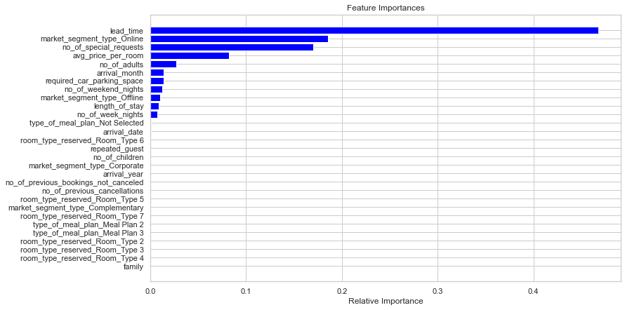

```python
# Importance of features
importances = estimator.feature_importances_
indices = np.argsort(importances)

plt.figure(figsize=(12, 7))
plt.title("Feature Importances")
plt.barh(range(len(indices)), importances[indices], color="blue", align="center")
plt.yticks(range(len(indices)), [feature_names[i] for i in indices])
plt.xlabel("Relative Importance")
plt.show()
```

- Top three important features after pre-pruning are lead time, market segment type online and number of special requests.

**Post-pruning**

```python
# Cost complexity pruning
clf = DecisionTreeClassifier(random_state=1, class_weight="balanced")
path = clf.cost_complexity_pruning_path(X_train, y_train)
ccp_alphas, impurities = abs(path.ccp_alphas), path.impurities
```

```python
pd.DataFrame(path)
```

|  | ccp_alphas | impurities |
| --- | --- | --- |
| 0 | 0.0 | 0.0 |
| 1 | 0.0 | 0.0 |
| 2 | 0.0 | 0.0 |
| 3 | 0.0 | 0.0 |
| 4 | 0.0 | 0.0 |
| ... | ... | ... |
| 1837 | 0.0 | 0.3 |
| 1838 | 0.0 | 0.3 |
| 1839 | 0.0 | 0.4 |
| 1840 | 0.0 | 0.4 |
| 1841 | 0.1 | 0.5 |

1842 rows × 2 columns

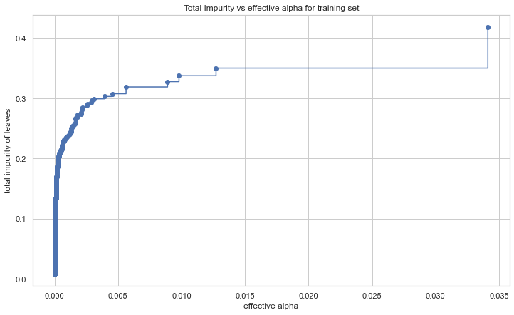

```python
fig, ax = plt.subplots(figsize=(12, 7))
ax.plot(ccp_alphas[:-1], impurities[:-1], marker="o", drawstyle="steps-post")
ax.set_xlabel("effective alpha")
ax.set_ylabel("total impurity of leaves")
ax.set_title("Total Impurity vs effective alpha for training set")
plt.show()
```

```python
# Training the decision tree
clfs = []
for ccp_alpha in ccp_alphas:
    clf = DecisionTreeClassifier(random_state=1, ccp_alpha=ccp_alpha, class_weight="balanced")
    clf.fit(X_train, y_train)
    clfs.append(clf)
print("Number of nodes in the last tree is: {} with ccp_alpha: {}".format(clfs[-1].tree_.node_count, ccp_alphas[-1]))
```

```
Number of nodes in the last tree is: 1 with ccp_alpha: 0.08117914389137304
```

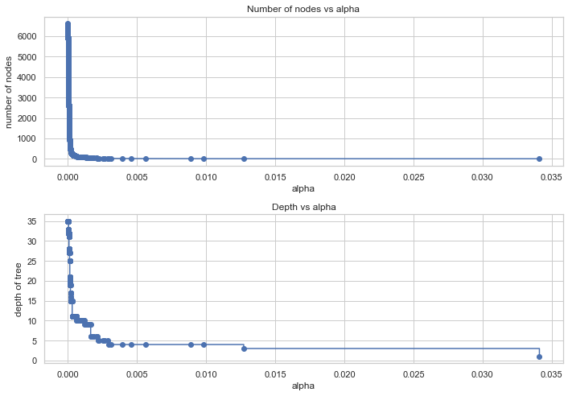

```python
# Removing last element in clfs and ccp alphas
clfs = clfs[:-1]
ccp_alphas = ccp_alphas[:-1]

node_counts = [clf.tree_.node_count for clf in clfs]
depth = [clf.tree_.max_depth for clf in clfs]
fig, ax = plt.subplots(2, 1, figsize=(10, 7))
ax[0].plot(ccp_alphas, node_counts, marker="o", drawstyle="steps-post")
ax[0].set_xlabel("alpha")
ax[0].set_ylabel("number of nodes")
ax[0].set_title("Number of nodes vs alpha")
ax[1].plot(ccp_alphas, depth, marker="o", drawstyle="steps-post")
ax[1].set_xlabel("alpha")
ax[1].set_ylabel("depth of tree")
ax[1].set_title("Depth vs alpha")
fig.tight_layout()
```

```python
# Looking at F1 score and alpha for training and test sets
f1_train = []
for clf in clfs:
    pred_train = clf.predict(X_train)
    values_train = f1_score(y_train, pred_train)
    f1_train.append(values_train)

f1_test = []
for clf in clfs:
    pred_test = clf.predict(X_test)
    values_test = f1_score(y_test, pred_test)
    f1_test.append(values_test)
```

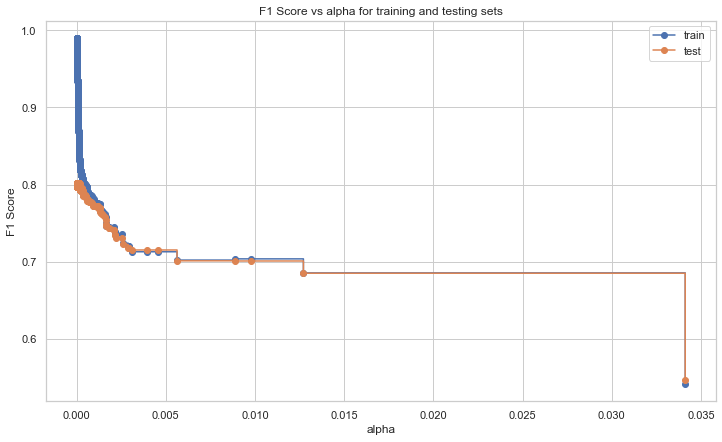

```python
fig, ax = plt.subplots(figsize=(12, 7))
ax.set_xlabel("alpha")
ax.set_ylabel("F1 Score")
ax.set_title("F1 Score vs alpha for training and testing sets")
ax.plot(ccp_alphas, f1_train, marker="o", label="train", drawstyle="steps-post")
ax.plot(ccp_alphas, f1_test, marker="o", label="test", drawstyle="steps-post")
ax.legend()
plt.show()
```

```python
index_best_model = np.argmax(f1_test)
best_model = clfs[index_best_model]
print(best_model)
```

```
DecisionTreeClassifier(ccp_alpha=7.993740069948972e-05, class_weight='balanced',
                       random_state=1)
```

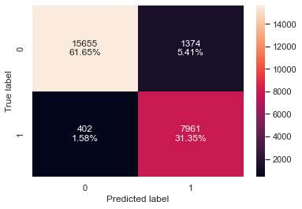

```python
# Checking model performance on training set
confusion_matrix_sklearn(best_model, X_train, y_train)
```

```python
dtree_post_perf_train = model_performance_classification_sklearn(best_model, X_train, y_train)
dtree_post_perf_train
```

|  | Accuracy | Recall | Precision | F1 |
| --- | --- | --- | --- | --- |
| 0 | 0.9 | 1.0 | 0.9 | 0.9 |

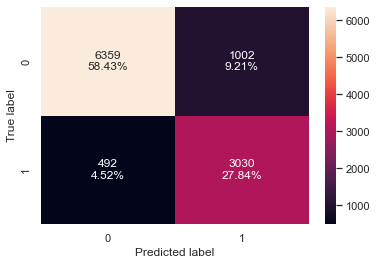

```python
# Checking model performance on testing set
confusion_matrix_sklearn(best_model, X_test, y_test)
```

```python
dtree_post_perf_test = model_performance_classification_sklearn(best_model, X_test, y_test)
dtree_post_perf_test
```

|  | Accuracy | Recall | Precision | F1 |
| --- | --- | --- | --- | --- |
| 0 | 0.9 | 0.9 | 0.8 | 0.8 |

[figure not shown]

```python
plt.figure(figsize=(20, 10))

out = tree.plot_tree(
    best_model,
    feature_names=feature_names,
    filled=True,
    fontsize=9,
    node_ids=False,
    class_names=None,
)
for o in out:
    arrow = o.arrow_patch
    if arrow is not None:
        arrow.set_edgecolor("black")
        arrow.set_linewidth(1)
plt.show()
```

```python
print(tree.export_text(best_model, feature_names=feature_names, show_weights=True))
```

```
|--- lead_time <= 21.64
|   |--- no_of_special_requests <= 0.50
|   |   |--- market_segment_type_Online <= 0.50
|   |   |   |--- lead_time <= 12.93
|   |   |   |   |--- length_of_stay <= 5.50
|   |   |   |   |   |--- avg_price_per_room <= 201.50
|   |   |   |   |   |   |--- no_of_weekend_nights <= 0.50
|   |   |   |   |   |   |   |--- market_segment_type_Offline <= 0.50
|   |   |   |   |   |   |   |   |--- lead_time <= 2.36
|   |   |   |   |   |   |   |   |   |--- avg_price_per_room <= 68.50
|   |   |   |   |   |   |   |   |   |   |--- weights: [207.26, 10.63] class: 0
|   |   |   |   |   |   |   |   |   |--- avg_price_per_room >  68.50
|   |   |   |   |   |   |   |   |   |   |--- arrival_date <= 29.50
|   |   |   |   |   |   |   |   |   |   |   |--- truncated branch of depth 9
|   |   |   |   |   |   |   |   |   |   |--- arrival_date >  29.50
|   |   |   |   |   |   |   |   |   |   |   |--- truncated branch of depth 2
|   |   |   |   |   |   |   |   |--- lead_time >  2.36
|   |   |   |   |   |   |   |   |   |--- avg_price_per_room <= 135.00
|   |   |   |   |   |   |   |   |   |   |--- arrival_month <= 11.50
|   |   |   |   |   |   |   |   |   |   |   |--- truncated branch of depth 7
|   |   |   |   |   |   |   |   |   |   |--- arrival_month >  11.50
|   |   |   |   |   |   |   |   |   |   |   |--- weights: [21.62, 0.00] class: 0
|   |   |   |   |   |   |   |   |   |--- avg_price_per_room >  135.00
|   |   |   |   |   |   |   |   |   |   |--- weights: [0.00, 12.14] class: 1
|   |   |   |   |   |   |   |--- market_segment_type_Offline >  0.50
|   |   |   |   |   |   |   |   |--- weights: [1199.59, 0.00] class: 0
|   |   |   |   |   |   |--- no_of_weekend_nights >  0.50
|   |   |   |   |   |   |   |--- lead_time <= 10.64
|   |   |   |   |   |   |   |   |--- arrival_date <= 27.50
|   |   |   |   |   |   |   |   |   |--- arrival_month <= 9.50
|   |   |   |   |   |   |   |   |   |   |--- lead_time <= 8.50
|   |   |   |   |   |   |   |   |   |   |   |--- truncated branch of depth 8
|   |   |   |   |   |   |   |   |   |   |--- lead_time >  8.50
|   |   |   |   |   |   |   |   |   |   |   |--- truncated branch of depth 4
|   |   |   |   |   |   |   |   |   |--- arrival_month >  9.50
|   |   |   |   |   |   |   |   |   |   |--- weights: [363.08, 22.77] class: 0
|   |   |   |   |   |   |   |   |--- arrival_date >  27.50
|   |   |   |   |   |   |   |   |   |--- lead_time <= 0.21
|   |   |   |   |   |   |   |   |   |   |--- arrival_month <= 2.50
|   |   |   |   |   |   |   |   |   |   |   |--- truncated branch of depth 2
```

[output cut: 855 more lines]

```
|   |   |   |   |   |   |--- weights: [5.96, 4.55] class: 0
|   |--- avg_price_per_room >  100.04
|   |   |--- arrival_month <= 11.50
|   |   |   |--- no_of_special_requests <= 2.50
|   |   |   |   |--- weights: [0.00, 3200.19] class: 1
|   |   |   |--- no_of_special_requests >  2.50
|   |   |   |   |--- weights: [23.11, 0.00] class: 0
|   |   |--- arrival_month >  11.50
|   |   |   |--- no_of_special_requests <= 0.50
|   |   |   |   |--- weights: [35.04, 0.00] class: 0
|   |   |   |--- no_of_special_requests >  0.50
|   |   |   |   |--- arrival_date <= 24.50
|   |   |   |   |   |--- weights: [3.73, 0.00] class: 0
|   |   |   |   |--- arrival_date >  24.50
|   |   |   |   |   |--- weights: [3.73, 22.77] class: 1
```

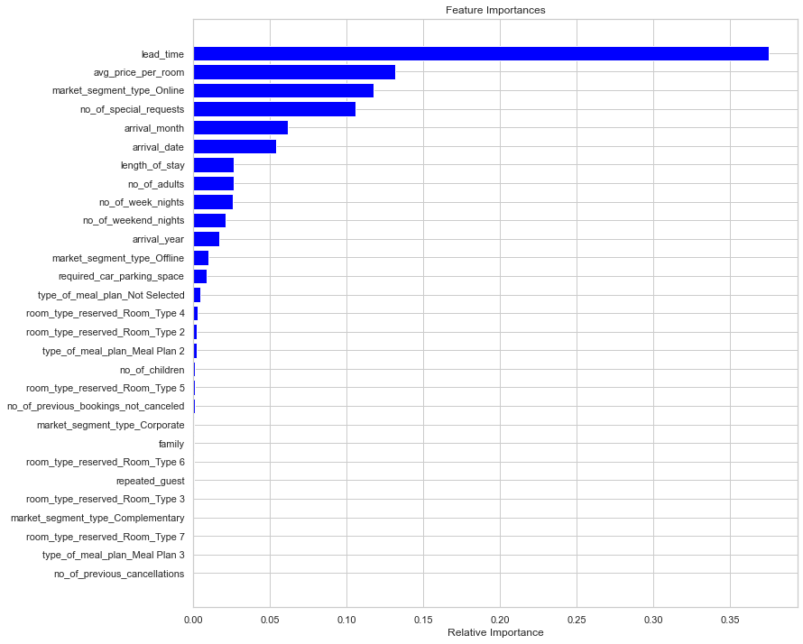

```python
# Looking at importances for the best model
importances = best_model.feature_importances_
indices = np.argsort(importances)

plt.figure(figsize=(12, 12))
plt.title("Feature Importances")
plt.barh(range(len(indices)), importances[indices], color="blue", align="center")
plt.yticks(range(len(indices)), [feature_names[i] for i in indices])
plt.xlabel("Relative Importance")
plt.show()
```

- Lead time, average price per room, and the online market segment type are the most important features for the post-pruned tree.

## Model Performance Comparison and Conclusions

```python
# Training model final comparison
models_train_comp_df = pd.concat(
    [
        dtree_perf_train.T,
        dtree_tune_perf_train.T,
        dtree_post_perf_train.T,
    ],
    axis=1,
)
models_train_comp_df.columns = [
    "Decision Tree sklearn",
    "Decision Tree (Pre-Pruning)",
    "Decision Tree (Post-Pruning)",
]
print("Training performance comparison:")
models_train_comp_df
```

```
Training performance comparison:
```

|  | Decision Tree sklearn | Decision Tree (Pre-Pruning) | Decision Tree (Post-Pruning) |
| --- | --- | --- | --- |
| Accuracy | 1.0 | 0.8 | 0.9 |
| Recall | 1.0 | 0.8 | 1.0 |
| Precision | 1.0 | 0.7 | 0.9 |
| F1 | 1.0 | 0.8 | 0.9 |

```python
# Testing model final comparison
models_test_comp_df = pd.concat(
    [
        dtree_perf_test.T,
        dtree_tune_perf_test.T,
        dtree_post_perf_test.T,
    ],
    axis=1,
)
models_test_comp_df.columns = [
    "Decision Tree sklearn",
    "Decision Tree (Pre-Pruning)",
    "Decision Tree (Post-Pruning)",
]
print("Testing performance comparison:")
models_test_comp_df
```

```
Testing performance comparison:
```

|  | Decision Tree sklearn | Decision Tree (Pre-Pruning) | Decision Tree (Post-Pruning) |
| --- | --- | --- | --- |
| Accuracy | 0.9 | 0.8 | 0.9 |
| Recall | 0.8 | 0.8 | 0.9 |
| Precision | 0.8 | 0.7 | 0.8 |
| F1 | 0.8 | 0.8 | 0.8 |

## Actionable Insights and Recommendations

- What profitable policies for cancellations and refunds can the hotel adopt?
- What other recommedations would you suggest to the hotel?

**Decision tree insights:**

- The model built can be used to predict if a guest is going to cancel their booking or not and can correctly identify 80% of booking cancelations.
- Lead time, average price per room, and the online market segment type are the most important variables in predicting whether a guest will cancel their booking or not.
- From the decision tree, it has been observed that if the lead time is <= 21.6 weeks, the number of special reqests is <= 0.5, the online market segment type is <=0.5, the lead time again is <= 12.93, the total length of stay is <= 5.5 days, and the average price per room is > 201.5, then the guest is most likely to fail.
1. What profitable policies for cancellations and refunds can the hotel adopt?
- The hotel can introduce cancelation policies such as, if a guest cancels at least 14 days prior to the booking date, then they can recieve a full refund, if they cancel at least 7 days prior to the booking date, they can recieve a 50% refund, and if they cancel within a week or are a no show, then they do not get a refund.
- The hotel could also offer the customer a credit or booking date change instead of a full or partial refund.
1. What other recommedations would you suggest to the hotel?
- I would suggest the hotel look into annual memberships or rates for the aviation and corporate markets. This could increase the amount of companies and airlines looking for accomodation for their employees to stay in. It can also boost the hotels brand name.
- As most cancelations happen during the middle of the year, they should investigate events or possible reasons cancelations are higher during this time of the year.
- The hotel should make sure their cancelation policies are clear on the online market as most bookings come through here, and they are also the highest market segement for cancelations.